# HW 4

### Enter your name and EID here: Andy Park, AP59864

**You will submit this homework assignment as a pdf file on Gradescope.**

*For all questions, include the R commands/functions that you used to find your answer (show R chunk). Answers without supporting code will not receive credit. Write full sentences to describe your findings.*

### Question 1: (2 pts)

First load the `tidyverse` package so that we can have access to the `tidyverse` data transformation functions. We also want to look at the `penguins` dataset, which is inside the `palmerpenguins` package:

```r
# Load tidyverse
library(tidyverse)

# If you get an error with this next line, you need to run install.packages("palmerpenguins") in the console
library(palmerpenguins)

# Save the data as a dataframe
penguins <- as_tibble(penguins)

# Take a look at the top of the data frame
penguins
```

```
## # A tibble: 344 × 8
##    species island    bill_length_mm bill_depth_mm flipper_length_mm body_mass_g
##    <fct>   <fct>              <dbl>         <dbl>             <int>       <int>
##  1 Adelie  Torgersen           39.1          18.7               181        3750
##  2 Adelie  Torgersen           39.5          17.4               186        3800
##  3 Adelie  Torgersen           40.3          18                 195        3250
##  4 Adelie  Torgersen           NA            NA                  NA          NA
##  5 Adelie  Torgersen           36.7          19.3               193        3450
##  6 Adelie  Torgersen           39.3          20.6               190        3650
##  7 Adelie  Torgersen           38.9          17.8               181        3625
##  8 Adelie  Torgersen           39.2          19.6               195        4675
##  9 Adelie  Torgersen           34.1          18.1               193        3475
## 10 Adelie  Torgersen           42            20.2               190        4250
## # ℹ 334 more rows
## # ℹ 2 more variables: sex <fct>, year <int>
```

Using a `tidyverse` function, keep all the rows/observations in the `penguins` dataset from the year 2007 and save the result as a new object called `penguins_2007`. Compare the number of observations/rows in the original `penguins` dataset with your new `penguins_2007` dataset.

```r
# Filter the penguins and compare the number of rows
penguins_2007 <- penguins %>%
  filter(year == 2007)

totalrow <- nrow(penguins)
rows2007 <- nrow(penguins_2007)

totalrow
```

```
## [1] 344
```

```r
rows2007
```

```
## [1] 110
```

**The original penguins dataset contains a total of 344 observations, and after filtering for the year 2007, the new object penguins_2007 contains 110 observations.**

### Question 2: (2 pts)

Using `tidyverse` functions on `penguins_2007`, report the number of observations for each species-island combination (note that you’ll need to `group_by`). Which species appears on all three islands?

```r
# Group penguins_2007 by species and island and count the observations in each group
species_island <- penguins_2007 %>%
  group_by(species, island) %>%
  summarise(n = n()) %>%
  arrange(species, island)

species_island
```

```
## # A tibble: 5 × 3
## # Groups:   species [3]
##   species   island        n
##   <fct>     <fct>     <int>
## 1 Adelie    Biscoe       10
## 2 Adelie    Dream        20
## 3 Adelie    Torgersen    20
## 4 Chinstrap Dream        26
## 5 Gentoo    Biscoe       34
```

**The species that appears on all three islands (Biscoe, Dream, and Torgersen) is Adelie.**

### Question 3: (2 pts)

Using `tidyverse` functions on `penguins_2007`, create a new variable that contains the ratio of `bill_length_mm` to `bill_depth_mm` (call it `bill_ratio`). *Once you checked that your variable is created correctly*, overwrite `penguins_2007` so it contains this new variable.

```r
# Create a new variable bill_ratio
penguins_2007 <- penguins_2007 %>%
  mutate(bill_ratio = bill_length_mm / bill_depth_mm)
```

Are there any cases in the `penguins_2007` dataset for which the `bill_ratio` exceeds 3.5? If so, for which species of penguins is this true?

```r
# Check for cases where bill_ratio exceeds 3.5.
exceedbill_ratio <- penguins_2007 %>%
  filter(bill_ratio > 3.5) %>%
  select(species, bill_ratio)

exceedbill_ratio
```

```
## # A tibble: 2 × 2
##   species bill_ratio
##   <fct>        <dbl>
## 1 Gentoo        3.51
## 2 Gentoo        3.51
```

**Yes, there are cases in the penguins_2007 dataset where the bill_ratio exceeds 3.5. This is true for the Gentoo species..**

### Question 4: (2 pts)

Using `tidyverse` functions on `penguins_2007`, find the three penguins with the smallest bill ratio for *each species*. Only display the information about `species`, `sex`, and `bill_ratio`. Does the same sex has the smallest bill ratio across species?

```r
# For each species, find the three penguins with the smallest bill_ratio and show species, sex, and bill_ratio
smallestbill_ratio <- penguins_2007 %>%
  group_by(species) %>%
  arrange(bill_ratio) %>%
  slice_head(n = 3) %>%
  select(species, sex, bill_ratio)

smallestbill_ratio
```

```
## # A tibble: 9 × 3
## # Groups:   species [3]
##   species   sex    bill_ratio
##   <fct>     <fct>       <dbl>
## 1 Adelie    male         1.64
## 2 Adelie    male         1.82
## 3 Adelie    male         1.86
## 4 Chinstrap female       2.43
## 5 Chinstrap female       2.43
## 6 Chinstrap female       2.45
## 7 Gentoo    male         2.93
## 8 Gentoo    female       2.99
## 9 Gentoo    female       3.01
```

### Question 5: (2 pts)

Using `tidyverse` functions on `penguins_2007`, calculate the mean and standard deviation of `bill_ratio` for each species. Drop NAs from `bill_ratio` for these computations (e.g., using the argument `na.rm = T`) so you have values for each species. Which species has the greatest mean `bill_ratio`?

```r
# Calculate the mean and standard deviation of bill_ratio for each species
billstats <- penguins_2007 %>%
  group_by(species) %>%
  summarise(mean_bill_ratio = mean(bill_ratio, na.rm = TRUE),
            sd_bill_ratio = sd(bill_ratio, na.rm = TRUE))

billstats
```

```
## # A tibble: 3 × 3
##   species   mean_bill_ratio sd_bill_ratio
##   <fct>               <dbl>         <dbl>
## 1 Adelie               2.07         0.152
## 2 Chinstrap            2.64         0.169
## 3 Gentoo               3.20         0.157
```

**Based on the tabple, the species with the greatest mean bill_ratio is Gentoo, with a mean of 3.203209..**

### Question 6: (2 pts)

Using `tidyverse` functions on `penguins_2007`, remove missing values for `sex`. Pipe a `ggplot` to create a single plot showing the distribution of `body_mass_g` colored by male and female penguins, faceted by species (use the function `facet_wrap()` with the option `nrow =` to give each species its own row). Which species shows the least sexual dimorphism (i.e., the greatest overlap of male/female size distributions)?

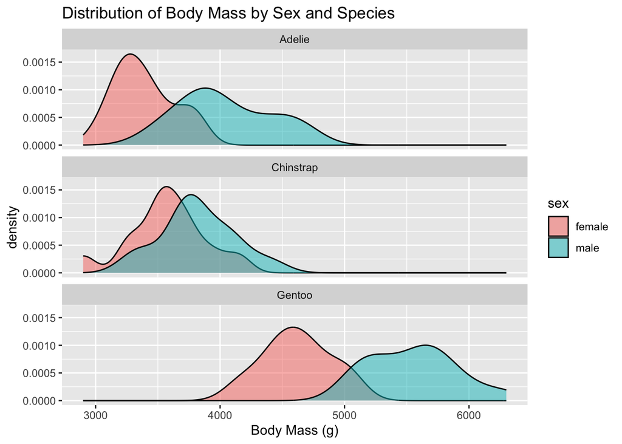

```r
# Remove rows with missing values for sex and create a ggplot for body_mass_g distributions by male and female penguins, faceted by species.
penguins_2007 %>%
  filter(!is.na(sex)) %>%
  ggplot(aes(x = body_mass_g, fill = sex)) +
  geom_density(alpha = 0.5) +
  facet_wrap(~ species, nrow = 3) +
  labs(x = "Body Mass (g)", title = "Distribution of Body Mass by Sex and Species")
```

**Chinstrap shows the least sexual dimorphism, as the distributions of body mass for male and female penguins have the greatest overlap compared to Adelie and Gentoo.**

### Question 7: (2 pts)

Pipe`penguins_2007` to `ggplot()` to create a scatterplot of `body_mass_g` (y-axis) against `bill_ratio` (x-axis). Does it look like there is a relationship between the bill ratio and the body mass? *Note: you might see a Warning message.* What does this message refer to?*

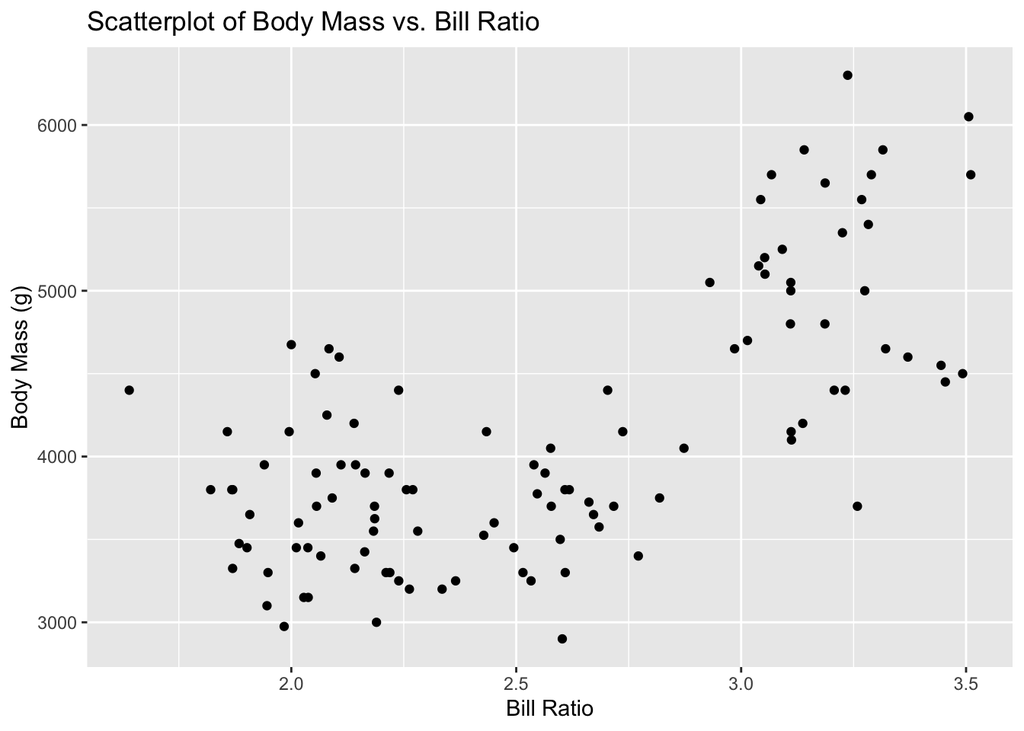

```r
# Scatterplot of body_mass_g vs bill_ratio for penguins_2007
ggplot(penguins_2007, aes(x = bill_ratio, y = body_mass_g)) +
  geom_point() +
  labs(x = "Bill Ratio", y = "Body Mass (g)",
       title = "Scatterplot of Body Mass vs. Bill Ratio")
```

**The scatterplot suggests that there is no strong linear relationship between bill ratio and body mass. However, Gentoo penguins, which have higher bill ratios, generally exhibit greater body mass compared to Adelie and Chinstrap species. The warning message likely refers to missing values in the bill ratio or body mass variables, which are excluded from the plot.**

### Question 8: (2 pts)

What if we separate each species? Duplicate the plot from the previous question and add a regression trend line with `geom_smooth(method = "lm")`. Color the points AND the regression lines by species. Does the relationship between the bill ratio and the body mass appear to be the same across the different species?

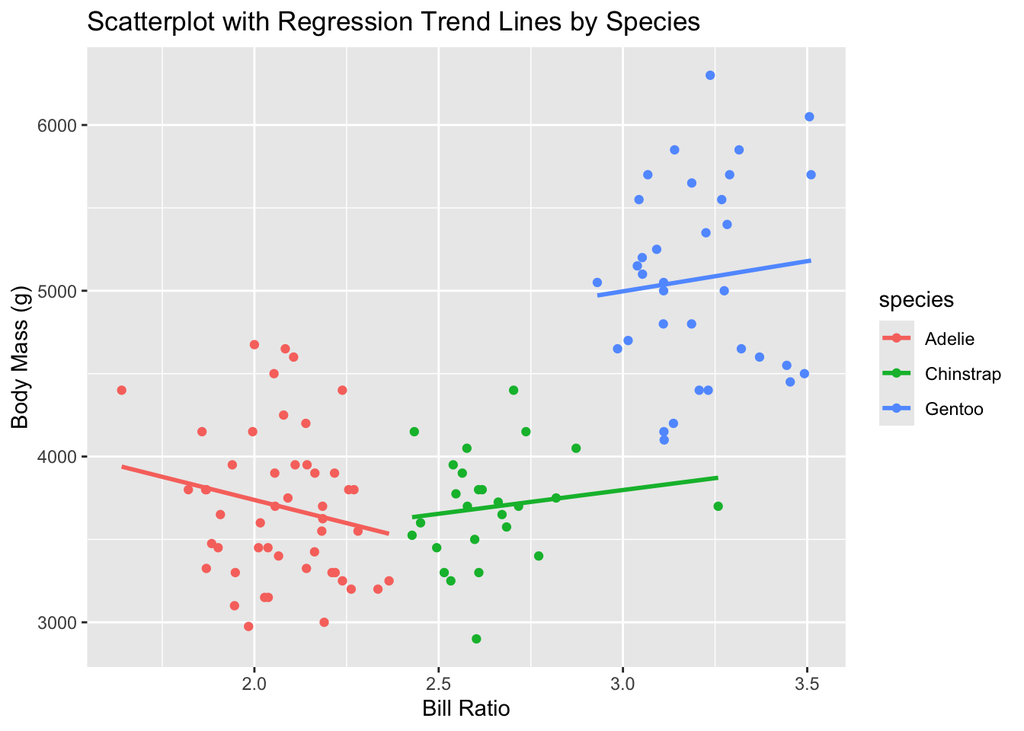

```r
# Create a scatterplot with a linear regression line, colored by species
ggplot(penguins_2007, aes(x = bill_ratio, y = body_mass_g, color = species)) +
  geom_point() +
  geom_smooth(method = "lm", se = FALSE) +
  labs(x = "Bill Ratio", y = "Body Mass (g)",
       title = "Scatterplot with Regression Trend Lines by Species")
```

**No, the relationship between bill ratio and body mass is not the same across the different species. For Adelie, the trend line shows a slight negative relationship, while Chinstrap shows a slightly positive trend. Gentoo displays a more pronounced positive relationship between bill ratio and body mass. This indicates that the association between bill ratio and body mass varies significantly among the species.**

### Question 9: (2 pts)

Finally, let’s make a plot using the original `penguins` dataset (not just the 2007 data). Forewarning: This will be very busy plot!

Map `body_mass_g` to the y-axis, `flipper_length_mm` to the x-axis, `species` to color, and `island` to shape. Using `facet_wrap()`, facet the plots by `year`. Find a way to clean up the x-axis labels (e.g., reduce the number of tick marks) using `scale_x_continuous()`. Does there appear to be a relationship between body mass and flipper length overall? Is there a relationship within each species? What happens to the distribution of flipper lengths for species over time?

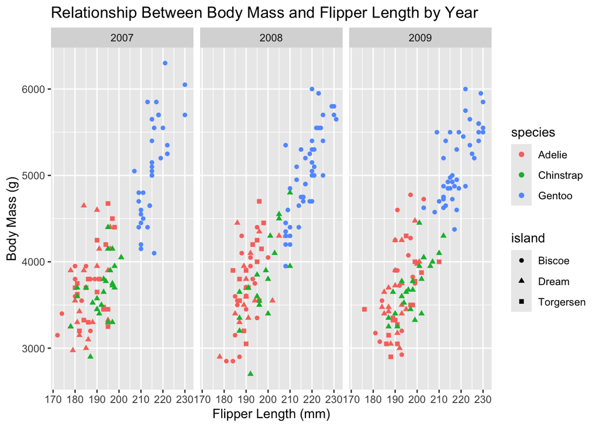

```r
# Create a busy plot using the original penguins dataset, mapping body_mass_g, flipper_length_mm, species, and island,
ggplot(penguins, aes(x = flipper_length_mm, y = body_mass_g, color = species, shape = island)) +
  geom_point() +
  facet_wrap(~ year) +
  scale_x_continuous(breaks = seq(170, 240, by = 10)) +
  labs(x = "Flipper Length (mm)", y = "Body Mass (g)",
       title = "Relationship Between Body Mass and Flipper Length by Year")
```

### Formatting: (2 pts)

Comment your code, write full sentences, and knit your file!